# Class Activity: categorical explanatory variables

In this activity, you will practice fitting a regression model with a quantitative response and a single categorical predictor.

## Setup

Researchers are interested in investigating the relationship between diet and wing length for fruit flies (*Drosophila melanogaster*). In an experiment, they randomly assign infant flies to one of three diet groups: Standard, Rich, and Poor. They then measure each fly’s wing length when they reach maturity.

You can load the data as follows:

```r
library(tidyverse)
drosophila <- read_csv("https://sta112-s26.github.io/class_activities/drosophila.csv")
```

Download the activity template: [activity template](https://sta112-s26.github.io/class_activities/ca_15_template.qmd)

### Modeling

We can visualize the relationship between diet and wing length with boxplots:

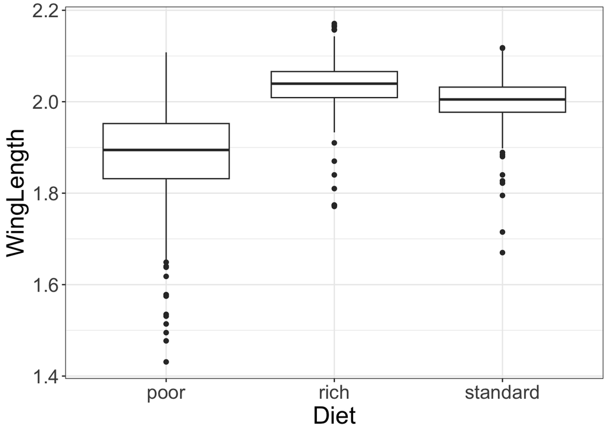

We will model this relationship as

$\text{WingLength} = \beta_0 + \beta_1 \text{IsRich} + \beta_2 \text{IsStandard} + \varepsilon$,

where $\text{IsRich}$ and $\text{IsStandard}$ are indicator variables for Diet:

There are lots of different notation for indicator variables. For example, R would call these indicators `Dietrich` and `Dietstandard`. Other notation includes $I_{\text{rich}}$ and $I_{\text{standard}}$.

$\text{IsRich} = \begin{cases} 0 & \text{Diet } \neq \text{rich} \\ 1 & \text{Diet } = \text{rich} \end{cases}$

$\text{IsStandard} = \begin{cases} 0 & \text{Diet } \neq \text{standard} \\ 1 & \text{Diet } = \text{standard} \end{cases}$

## Questions

1. Use the `lm` function to fit the regression model with Diet as the predictor and WingLength as the response.
2. What is the estimated average WingLength for drosophila in each diet type?
3. How many degrees of freedom does the fitted model from question 1 have?